# Replication of Study 5 by Reis et al. (2018, Journal of Experimental Social Psychology)

Catherine Garton (cgarton@stanford.edu)

December 08, 2022

## Introduction

### Background

In a fascinating series of experiments published in JESP, Reis and colleagues (2018) examined the interpersonal influences on intellectual humility (IH)[^1]. The authors hypothesized that priming the social cue of partner responsiveness would boost IH, because feeling understood may decrease people’s propensity for self-enhancement and allow them to respond to their environment more openly. Study 5, which I will attempt to replicate, finds that priming partner responsiveness promotes a broader cognitive perspective (as measured in a global-local visual orientation task). The authors imply that a broader perspective may be the cognitive underpinnings of intellectual humility.

### Justification

Intellectual humility has been the backbone of my research interests. The affective roots of IH are incredibly understudied, and I am hoping to explore the roles of threat and competition (vs. psychological safety and trust) in enabling intellectual humility about morally divisive or identity-based beliefs. This is the most relevant paper in the extant literature, because it provides preliminary evidence that feelings of safety and support increase cognitive openness.

### Stimuli and procedures

Participants will be recruited from Prolific and randomized to one of two conditions[^2]: responsive or unresponsive partner. In the responsive (vs. unresponsive) condition, participants are asked to describe 2 (vs. 10) kind or considerate things their partner had done for them in the past week. It is generally easy to think of 2 such examples and harder to think of 10; this relative availability primes confidence or doubt in one’s partner’s responsiveness. Then participants complete 16 trials of the global-local visual orientation task (see example image below). Finally, participants complete the 20-item PANAS measure of mood, a potential confounding variable. The survey can be implemented in Qualtrics and should take roughly 8 minutes per participant.

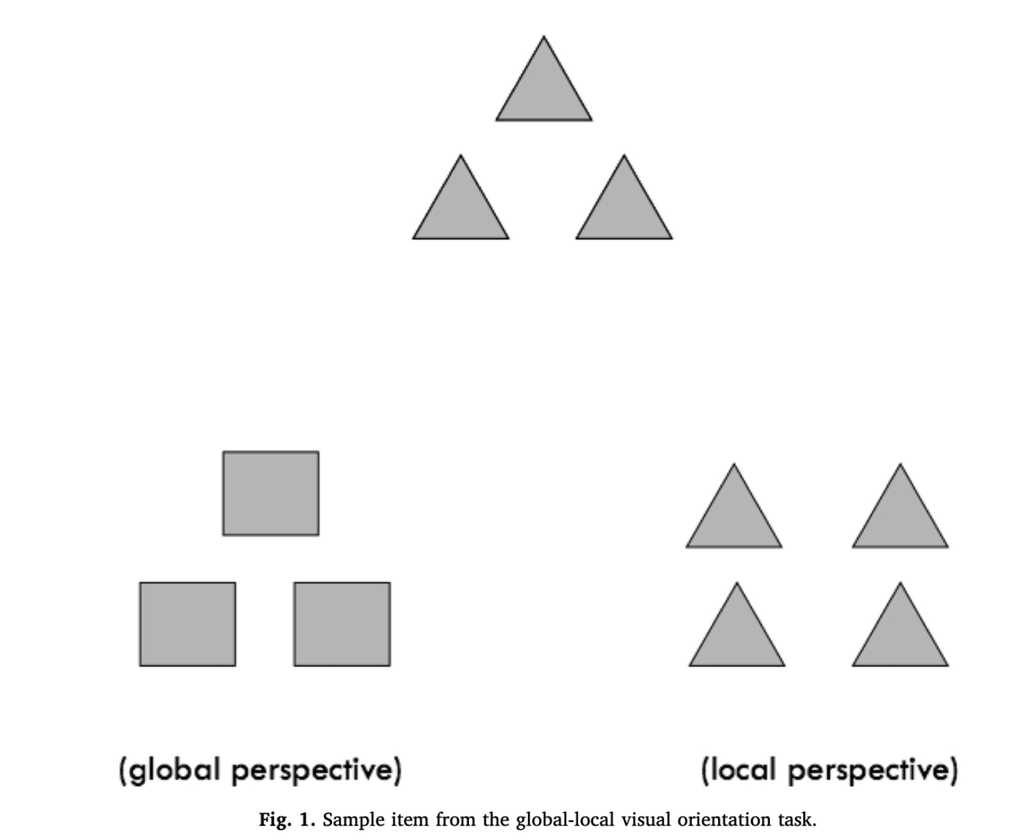

Fig. 1, Reis et al. (2018), p. 30

### Anticipated challenges

- Appropriate power. The authors recruited 225 participants per condition, for a target of 188 after deletions, based on expected effect sizes. In a post-hoc power analysis (based on the magnitude of the effect the authors found, assuming no bias in the estimate), their sample size afforded 99% power. Given the budget for this class, I proposed a target sample of 180 participants after exclusions[^3] (90 per condition), which would provide only 80% power for an effect size of the same magnitude, **d** = .37. Thus, given the sample size constraints, I will have less power than the original study.

### Links

View the project repository on Github: [Psych 251 repo](https://github.com/psych251/reis2018)

View the original paper: [Reis et al., 2018](https://github.com/psych251/reis2018/blob/main/original_paper/Reis_et_al_2018.pdf)

View the replication survey: [Qualtrics](https://stanforduniversity.qualtrics.com/jfe/form/SV_783wI0qv7YyaeXA)

## Methods

### Power Analysis

I used G*power to conduct a power analysis for a between-subjects, unpooled, one-tailed t-test. Given the original effect size, I would need 180 participants to have 80% power to detect the effect at alpha = .05. I expect a significant number of participants to fail the attention check, so with 15% buffer for exclusions, I aim to recruit 212 participants.

### Planned Sample

Using Prolific, I will recruit English-speaking adults (*n* = 212). I will terminate data collection when I have reached this predetermined sample size, as indicated by my power analysis. There are no other pre-selection rules.

### Materials

Participants will complete a survey hosted by Qualtrics. They will view and select geometric images as part of a 16-trial global-local visual orientation task originally developed by Kimchi & Palmer (1982). Survey materials and images can be found on the [Harvard Dataverse](https://dataverse.harvard.edu/privateurl.xhtml?token=f8d2d590-6a8e-4df2-9dca-7e3f3813c78c).

### Procedure

To mimic the original study exactly, the study title will advertised as “relationships and perception”. Individuals who enroll in the study on Prolific will be redirected to a Qualtrics survey, where they will provide informed consent before continuing:

**1. Manipulation**: Participants will first complete a writing prompt based on one of two randomized conditions. I will follow the original authors’ procedure for the responsive (unresponsive) conditions by asking, “Please describe **2 (10) kind or considerate** things your partner has done to help you **in the last 7 days.**” Participants are then given 2 (10) short-answer text boxes to fill in their answers. Note that participants are instructed to complete the question about a close friend if they are not currently in a romantic relationship.

**2. Global-local visual orientation task** (following Reis & colleagues’ protocol exactly):

> On each trial, participants were shown a screen with a geometric shape (composed of triangles or squares) on top and beneath this single shape, two images containing multiple shapes. The participant is asked to judge whether the single shape is more similar to the lower-right or lower-left image. . . . Across trials, the right-left position of the global-local option was counterbalanced, as was the shape associated with each option. (Reis et al., 2019, p. 29)

**3. Mood**: After this task, participants will complete the 20-item PANAS (Watson, Clark, & Tellegen, 1988) to assess their mood.

**4. Attention check & demographics**: Finally, participants will respond to a manipulation check (i.e., the ease or difficulty of the relationship recall task), an attention check, and a demographic question about their sex.

### Analysis Plan

#### Data cleaning

Participants will be excluded from analysis if any of the following criteria apply (according to reasons cited by the original authors):

- failing the attention check
- leaving the relationship recall task items blank
- skipping more than half of the global-local visual orientation trials
- choosing the same response on all 16 trials[^4]

#### Data processing

The independent variable, perceived responsiveness, will be captured by Qualtrics embedded data according to the participant’s randomized condition.

The dependent variable, cognitive broadening, will be calculated by summing the number of trials of which participants selected the “global processing” figure (i.e., the figure with pattern-based similarity rather than constituent-shape similarity). Note: Based on a reproducibility analysis I completed with the authors’ public data, I determined that the authors first summed global processing scores within the first 8 trials (which contained small figures containing 3-4 blocks each) and within the last 8 trials (which contained large figures containing 9-10 blocks each). Within each of these sets, they interpolated any NA values by calculating the mean likelihood of a global-processing choice for the completed trials and substituting that value for the missing trial(s). They then summed the small-figure trials and large-figure trials to create a composite global processing score, which was used for the ANOVA. I will follow the authors’ analytic choices to preserve the consistency of the replication.

A current mood score will be created by subtracting the mean score across negative items from the mean score across positive items.

#### Key analysis

The key analysis is a between-subjects unpaired t-test on the global-processing mean scores between the responsive and unresponsive conditions. A significant mean difference, such that the responsive condition shows a higher global processing score, would replicate the original finding. If a significant difference is found, I am also interested to see if the magnitude of the effect size is similar.

#### Additional analyses

Additional analyses will see if the effect persists after controlling for mood, as well as test for an interaction with participant sex, to see if the authors’ other primary findings replicate.

For my own curiosity, I will also rerun all analyses without any data exclusions, as the original exclusions were substantial.

Because the original dataset is public, I will also run a t-test between conditions in their data and compare my findings to that re-analysis (which more closely matches the statistical test I will be using).

### Differences from Original Study

1. In the original study, participants were not compensated for participating, whereas in this replication attempt, participants will be compensated monetarily. I do not expect this to make a difference in the effect of interest. While participants might be differently motivated, this should not bias the effect in a particular direction.
2. This replication attempt is underpowered to support a 3rd condition (the neutral control), so it will only examine the difference between the responsive and unresponsive conditions, rather than conducting an ANOVA between all three. This will make a difference in the computation of the effect, given that I will end up conducting a t-test (using the independent variance from two groups) rather than the authors’ post-hoc Fisher’s LSD test (which would use the pooled variance from all three). However, I will also conduct the same statistical test on the authors’ original data and compare my results to that as well.
3. The authors included some additional questions[^5] in their survey materials. These items are not part of the specific effect I am planning to replicate, so I am excluding them from the survey for the sake of time. Because these measures were collected after both the manipulation and DV task, I do not expect them to make a difference in the effect of interest.
4. I decided to use a different attention check that is more straightforward and may be perceived less like we are trying to ‘trick’ or ‘catch’ participants. This change would only impact the effect of interest if mine or the authors’ original attention check selectively excluded participants from one condition more than the other. I do not know if this was the case for the original study, but I will confirm in my sample that roughly equal numbers of participants were excluded from each condition.

### Methods Addendum (Post Data Collection)

#### Actual Sample

I recruited 212 English-speaking adults on Prolific. After exclusions, I was left with 208 participants for analysis. Consistent with Reis et al. (2018), the only demographic we collected was gender: Our sample composed of 40.9% male, 56.3% female, and 2.8% non-binary.

#### Differences from pre-data collection methods plan

Before launching the survey, the original authors advised me that they had randomized the global-local processing trials. I updated my reimplementation accordingly. Unfortunately, by adding randomization to each question of the task, Qualtrics eliminated the page breaks I had placed between trials. This means that all trials were presented on the same page. Additionally, since questions had been designed to auto-advance, after selecting their first answer participants got a warning message asking if they wanted to proceed to the next page despite skipping 15 questions, or stay on the page and answer the rest. We still received complete data from almost all participants, so it seems like most people made it through this step. However, the task may have been more confusing to participants than we intended for this reason. Encouragingly, only one participant complained about this in the comment box of the survey, and all other comments indicated that the survey was smooth and enjoyable.

## Results

### Reproducing author results

First, I will reproduce the authors’ results from their public data, and I will run a t-test between the responsive and unresponsive conditions so that I have a directly comparable statistical test.

```r
####Load Relevant Libraries and Functions
library(tidyverse)
library(haven)

#Reproducing original author analysis
authordata <- read_sav(here("data/original_authordata/study5.sav"))

m <- aov(Globaltotal_total ~ Conditions, data = authordata)
summary(m)
```

```
##              Df Sum Sq Mean Sq F value  Pr(>F)
## Conditions    2    269   134.7   6.067 0.00249 **
## Residuals   517  11479    22.2
## ---
## Signif. codes:  0 '***' 0.001 '**' 0.01 '*' 0.05 '.' 0.1 ' ' 1
```

```r
authordata %>%
  group_by(condition) %>%
  summarize(mean = mean(Globaltotal_total),
            sd = sd(Globaltotal_total))
```

```
## # A tibble: 3 × 3
##   condition         mean    sd
##   <dbl+lbl>        <dbl> <dbl>
## 1 1 [Unresponsive]  10.5  5.04
## 2 2 [Control]       11.5  4.70
## 3 3 [Responsive]    12.3  4.38
```

I was able to reproduce the same means and test statistics as the original article. [Unresponsive: M = 10.5, SD = 5.04. Responsive: M = 12.3, SD = 4.38.] The ANOVA between the three conditions yielded F = 6.07(2,517), p = .002.

```r
#Determining test statistic from t-test between conditions of interest in the authors' original data
authordata_subset <- subset(authordata, Conditions != "Control")
t.test(Globaltotal_total ~ Conditions, authordata_subset)
```

```
##
##  Welch Two Sample t-test
##
## data:  Globaltotal_total by Conditions
## t = 3.4647, df = 337.82, p-value = 0.0005993
## alternative hypothesis: true difference in means between group Responsive and group Unresponsive is not equal to 0
## 95 percent confidence interval:
##  0.7570397 2.7456412
## sample estimates:
##   mean in group Responsive mean in group Unresponsive
##                   12.26512                   10.51377
```

The statistical test I will be directly comparing to is the t-test between the unresponsive and responsive conditions. This resulted in a value of p = .0006, t(337.82) = 3.46, same means and standard deviations.

### Data preparation

Next I will turn to the equivalent analysis of my replication data.

##### Importing data

```r
####Import data
df_names <- read_csv(here("data/anon_rawdata/rawdata_anon.csv"), n_max=0) %>% names()
rawdata <- read_csv(here("data/anon_rawdata/rawdata_anon.csv"),
                    col_names = df_names,
                    col_types = "d",
                    skip = 3)
```

##### Cleaning data

```r
#### Data exclusion / filtering

skipped.morethan.8 <- function(row){
    ifelse(sum(is.na(row))>=8, 1,0)
}

same.response.16 <- function(row){
  ifelse(sum(row)==16 | sum(row)==0, 1,0)
}

rrt.blank <- function(row){
  ifelse(is_empty(row)==TRUE, 1,0)
}

rawdata$exclude_skipped <- apply(select(rawdata, starts_with("trial_")),MARGIN=1, FUN=skipped.morethan.8)

rawdata$exclude_sameresponse <- apply(select(rawdata, starts_with("trial_")),MARGIN=1, FUN=same.response.16)

rawdata$exclude_rrt_blank <- apply(select(rawdata, starts_with("rrt_")),MARGIN=1, FUN=rrt.blank)

cleandata <- rawdata %>%
  filter(Finished == 1 & attn_check_fruit == 1 & exclude_skipped == 0 & exclude_sameresponse==0 & exclude_rrt_blank==0)

dim(cleandata)
```

```
## [1] 208  78
```

There were only 4 exclusions, leaving a final sample of n = 208. There were an equal number of exclusions in each experimental condition.

##### Creating variables of interest

```r
# Converting some variables to factors
cleandata$condition <- as.factor(cleandata$condition)
cleandata$gender <- as.factor(cleandata$gender)
cleandata$prior_knowledge_rrt <- as.factor(cleandata$prior_knowledge_rrt)

#### Creating NA imputation function
na.mean <- function(row){
    replace(row,is.na(row)==T,mean(row, na.rm=T))
}

#### Imputing NA values for small and large trials

cleandata[,c(names(select(cleandata, starts_with("trial_sm"))))] <- sapply(cleandata[,c(names(select(cleandata, starts_with("trial_sm"))))], na.mean)

cleandata[,c(names(select(cleandata, starts_with("trial_lg"))))] <- sapply(cleandata[,c(names(select(cleandata, starts_with("trial_lg"))))], na.mean)

#### Prepare data for analysis - create columns etc.
data <- cleandata %>%
  mutate(global_small = rowSums(select(cleandata, starts_with("trial_sm")), na.rm = TRUE)) %>%
  mutate(global_large = rowSums(select(cleandata, starts_with("trial_lg")), na.rm = TRUE)) %>%
  mutate(global_total = global_small + global_large) %>%
  mutate(positive = rowMeans(cleandata[,c("panas_1", "panas_3", "panas_5", "panas_9", "panas_10", "panas_12", "panas_14", "panas_16", "panas_17", "panas_19")])) %>%
  mutate(negative = rowMeans(cleandata[,c("panas_2", "panas_4", "panas_6", "panas_7", "panas_8", "panas_11", "panas_13", "panas_15", "panas_18", "panas_20")])) %>%
  mutate(mood = positive - negative) %>%
  unite("partner", c(partner_type_u, partner_type_r), na.rm=TRUE) %>%
  mutate(partner = as.factor(partner)) %>%
  unite("difficulty", c(difficulty_u, difficulty_r), na.rm=TRUE) %>%
  mutate(difficulty = as.numeric(difficulty)) %>%
  select(c("condition", "global_small", "global_large", "global_total", "mood", "gender", "partner", "prior_knowledge_rrt", "difficulty", "device")) %>%
  mutate("id" = seq(1,208, by = 1))
```

### Descriptive Checks

##### Condition

First, I will assess how many people ended up in each condition.

```r
table(data$condition)
```

```
##
##   responsive unresponsive
##          110           98
```

```r
t.test(id ~ condition, data)
```

```
##
##  Welch Two Sample t-test
##
## data:  id by condition
## t = -1.4863, df = 198.64, p-value = 0.1388
## alternative hypothesis: true difference in means between group responsive and group unresponsive is not equal to 0
## 95 percent confidence interval:
##  -28.956782   4.066244
## sample estimates:
##   mean in group responsive mean in group unresponsive
##                   98.63636                  111.08163
```

Although the experiment was designed to allocate people equally into each group, more participants ended up in the responsive condition (110) than the unresponsive condition (98), probably due to people dropping out of the unresponsive condition after starting the survey. It is unclear why more people dropped out of the unresponsive condition. I ran a t-test between conditions, which was not significant, suggesting that this allocation may be compatible with random chance. Alternatively, the unresponsive condition may have induced negative emotions, causing participants in that condition to want to stop the study more frequently.

##### Manipulation

Next I’ll run a manipulation check to see if the relationship recall task was indeed harder for participants in the unresponsive condition.

```r
t.test(difficulty ~ condition, data)
```

```
##
##  Welch Two Sample t-test
##
## data:  difficulty by condition
## t = -3.6756, df = 195.43, p-value = 0.0003065
## alternative hypothesis: true difference in means between group responsive and group unresponsive is not equal to 0
## 95 percent confidence interval:
##  -0.9458840 -0.2852848
## sample estimates:
##   mean in group responsive mean in group unresponsive
##                   2.027273                   2.642857
```

The unresponsive writing condition was indeed more challenging, with Mdiff = .61 (on a 1-5 scale), p = .0003. The manipulation was successful.

##### Gender distribution

Next I will check the distribution of gender across conditions.

```r
data$gender <- ifelse(data$gender==1, "Male", ifelse(data$gender == 2, "Female", "Non-binary"))
table(data$condition, data$gender)
```

```
##
##                Female Male Non-binary
##   responsive       63   44          3
##   unresponsive     54   41          3
```

According to this table, there were slightly more females in the responsive condition than the unresponsive condition, while men were fairly evenly split.

### Confirmatory analysis

#### Primary statistical test

Now I will move to the single confirmatory test: a t-test of the global processing scores between conditions.

```r
t.test(global_total ~ condition, data)
```

```
##
##  Welch Two Sample t-test
##
## data:  global_total by condition
## t = -1.3891, df = 202.44, p-value = 0.1663
## alternative hypothesis: true difference in means between group responsive and group unresponsive is not equal to 0
## 95 percent confidence interval:
##  -2.156434  0.373874
## sample estimates:
##   mean in group responsive mean in group unresponsive
##                   9.445455                  10.336735
```

The means were not statistically different between groups (p = .166, 95% CI = [-2.16, .37]). Interestingly, the mean difference also trended in the unexpected direction. The mean of the responsive group was 9.45 trials, and the mean in the unresponsive group was 10.34 trials.

#### Primary results table

```r
table <- data %>%
  group_by(condition) %>%
  summarize(global = round(mean(global_total),2), sd = round(sd(global_total, na.rm=T),2), n = n()) %>%
  t() %>%
  as.data.frame()

table
```

```
##                   V1           V2
## condition responsive unresponsive
## global          9.45        10.34
## sd              4.58         4.65
## n                110           98
```

Compare to original table:

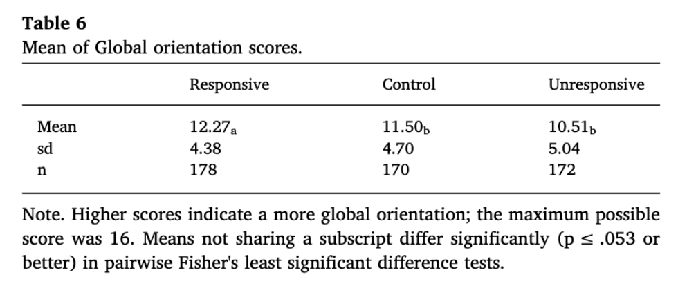

Table 6, Reis et al. (2018), p. 30

#### Visualizing the results

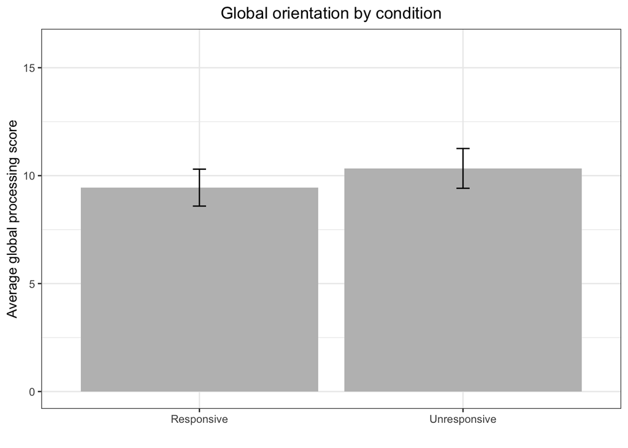

```r
plotdata <- data %>%
  group_by(condition) %>%
  dplyr::summarize(avgscore = mean(global_total), sd = sd(global_total, na.rm = T), n =n()) %>%
  mutate(upper = (avgscore + (sd/sqrt(n))*1.96), lower = (avgscore - (sd/sqrt(n))*1.96))


ggplot(plotdata, aes(x=condition, y=avgscore)) +
  geom_col(fill="gray") +
  geom_errorbar(aes(ymin=lower,ymax=upper), width = .05) +
  labs(y = "Average global processing score", x = "", title = "Global orientation by condition") +
  coord_cartesian(ylim = c(0,16)) +
  scale_x_discrete(labels=c("Responsive", "Unresponsive")) +
  theme_bw() +
  theme(plot.title = element_text(hjust=.5))
```

Note: this is just for visualization purposes. There was no comparison figure in original article.

### Exploratory analyses

Below I test four exploratory models: (a) Consistent with the authors, I tested whether the effect of condition on global processing exists when controlling for positive/negative affect. (b) Consistent with the authors, I tested whether the effect of condition on global processing is moderated by gender. (c) For my own curiosity, I tested whether the results differed depending on whether the relationship partner chosen in the priming task was a close friend or romantic partner. (d) For my own curiosity, I tested whether the results were impacted by the way the trials were displayed on different devices (e.g., phone vs. laptop).

```r
# a
# controlling for mood
summary(lm(global_total ~ condition + mood, data))
```

```
##
## Call:
## lm(formula = global_total ~ condition + mood, data = data)
##
## Residuals:
##     Min      1Q  Median      3Q     Max
## -9.5584 -3.4082  0.7889  4.3774  5.9157
##
## Coefficients:
##                       Estimate Std. Error t value Pr(>|t|)
## (Intercept)             9.3274     0.5069  18.402   <2e-16 ***
## conditionunresponsive   0.8490     0.6475   1.311    0.191
## mood                   -0.3473     0.7309  -0.475    0.635
## ---
## Signif. codes:  0 '***' 0.001 '**' 0.01 '*' 0.05 '.' 0.1 ' ' 1
##
## Residual standard error: 4.633 on 204 degrees of freedom
##   (1 observation deleted due to missingness)
## Multiple R-squared:  0.009999,   Adjusted R-squared:  0.0002934
## F-statistic:  1.03 on 2 and 204 DF,  p-value: 0.3588
```

```r
# b
# interaction with gender
summary(lm(global_total ~ condition*gender, data))
```

```
##
## Call:
## lm(formula = global_total ~ condition * gender, data = data)
##
## Residuals:
##    Min     1Q Median     3Q    Max
## -9.556 -3.508  1.049  4.444  5.614
##
## Coefficients:
##                                        Estimate Std. Error t value Pr(>|t|)
## (Intercept)                              9.5079     0.5861  16.221   <2e-16 ***
## conditionunresponsive                    1.0476     0.8628   1.214    0.226
## genderMale                              -0.1216     0.9140  -0.133    0.894
## genderNon-binary                        -0.5079     2.7492  -0.185    0.854
## conditionunresponsive:genderMale        -0.4828     1.3282  -0.363    0.717
## conditionunresponsive:genderNon-binary   1.6190     3.8953   0.416    0.678
## ---
## Signif. codes:  0 '***' 0.001 '**' 0.01 '*' 0.05 '.' 0.1 ' ' 1
##
## Residual standard error: 4.652 on 202 degrees of freedom
## Multiple R-squared:  0.01268,    Adjusted R-squared:  -0.01176
## F-statistic: 0.5189 on 5 and 202 DF,  p-value: 0.7618
```

```r
# c
# interaction with partner category
summary(lm(global_total ~ condition*partner, data))
```

```
##
## Call:
## lm(formula = global_total ~ condition * partner, data = data)
##
## Residuals:
##    Min     1Q Median     3Q    Max
## -9.800 -3.688  1.011  4.200  6.312
##
## Coefficients:
##                                Estimate Std. Error t value Pr(>|t|)
## (Intercept)                      8.6875     0.8124  10.693   <2e-16 ***
## conditionunresponsive            0.4911     1.1892   0.413    0.680
## partner2                         1.0689     0.9648   1.108    0.269
## conditionunresponsive:partner2   0.5525     1.4095   0.392    0.695
## ---
## Signif. codes:  0 '***' 0.001 '**' 0.01 '*' 0.05 '.' 0.1 ' ' 1
##
## Residual standard error: 4.596 on 204 degrees of freedom
## Multiple R-squared:  0.02703,    Adjusted R-squared:  0.01272
## F-statistic: 1.889 on 3 and 204 DF,  p-value: 0.1326
```

```r
# d
# does device independently matter?
summary(lm(global_total ~ device, data))
```

```
##
## Call:
## lm(formula = global_total ~ device, data = data)
##
## Residuals:
##    Min     1Q Median     3Q    Max
## -8.985 -3.810  1.190  4.190  5.190
##
## Coefficients:
##             Estimate Std. Error t value Pr(>|t|)
## (Intercept)   9.9848     0.5706  17.498   <2e-16 ***
## device       -0.1750     0.6906  -0.253      0.8
## ---
## Signif. codes:  0 '***' 0.001 '**' 0.01 '*' 0.05 '.' 0.1 ' ' 1
##
## Residual standard error: 4.636 on 206 degrees of freedom
## Multiple R-squared:  0.0003116,  Adjusted R-squared:  -0.004541
## F-statistic: 0.0642 on 1 and 206 DF,  p-value: 0.8002
```

None of the variables in these models reach significance. This suggests that–at least in my sample–there was no effect of condition, mood, gender, partner type, or device type on global-processing scores.

Finally, I tested whether my results changed meaningfully when I included all participants (no exclusions).

```r
completedata <- rawdata

# Converting some variables to factors
completedata$condition <- as.factor(completedata$condition)

completedata[,c(names(select(completedata, starts_with("trial_sm"))))] <- sapply(completedata[,c(names(select(completedata, starts_with("trial_sm"))))], na.mean)

completedata[,c(names(select(completedata, starts_with("trial_lg"))))] <- sapply(completedata[,c(names(select(completedata, starts_with("trial_lg"))))], na.mean)

#### Prepare data for analysis - create columns etc.
completedata <- completedata %>%
  mutate(global_small = rowSums(select(completedata, starts_with("trial_sm")), na.rm = TRUE)) %>%
  mutate(global_large = rowSums(select(completedata, starts_with("trial_lg")), na.rm = TRUE)) %>%
  mutate(global_total = global_small + global_large)

dim(completedata) # There are now 212 participants
```

```
## [1] 212  81
```

```r
t.test(global_total ~ condition, completedata)
```

```
##
##  Welch Two Sample t-test
##
## data:  global_total by condition
## t = -1.2124, df = 205.16, p-value = 0.2267
## alternative hypothesis: true difference in means between group responsive and group unresponsive is not equal to 0
## 95 percent confidence interval:
##  -2.0310062  0.4842427
## sample estimates:
##   mean in group responsive mean in group unresponsive
##                   9.457171                  10.230553
```

The results did not change. This is unsurprising, since there were only 4 exclusions. I would be interested in running this analysis on the original authors’ pre-cleaned dataset, which had a higher percentage of exclusions.

## Discussion

### Summary of Replication Attempt

The original finding was that participants in the responsive condition had significantly higher global processing scores (12.27 trials) than participants in the unresponsive condition (10.51 trials), p = .0006.

### Commentary

The results across studies are inconclusive, and it’s unclear why the effect did not replicate. Without more faithful replications in the future, I am unsure whether the true effect is better represented by the original study or my replication attempt. A few noteworthy differences come to mind, however.

- The original study had a larger sample size (178 and 172 in the responsive and unresponsive conditions, respectively) than this replication attempt (110 and 98, respectively). A larger sample is less likely to produce unhappy randomization and spurious results.
- Selective attrition could have also skewed the result of my replication attempt. For example, the 12 participants from the unresponsive condition who stopped early might have otherwise brought down the global mean of that group.
- The main methodological difference between the original study and the replication was the nature of the attention check. In Reis et al. (2018), the attention check required participants to carefully read a paragraph-long block of text, ignore the next question they were asked, and type something else they had previously been instructed into the box. In order to get this question right, participants had to be sufficiently detail-oriented to read the whole paragraph and spot the correct answer. (30% of participants failed and were excluded.) This could confound the experimental task, which tests whether people focus on big-picture patterns or the details of constituent parts. Thus, it is possible that participants with higher dispositional global processing were disproportionately excluded from the original study and that this could have accidentally deflated the unresponsive condition.
- Finally, my reimplementation survey had a glitch that caused all of the trials to display on the same page. I don’t think this should have biased one condition over another, but it does make my replication less neat and adds potential random noise.

### Appreciation for author input

Professor Reis was extremely helpful in reviewing my materials and providing feedback. He noticed two discrepancies in my implementation prior to launch, including the lack of figure randomization and the presence of an additional question that wasn’t in the original; I updated both discrepancies accordingly. Professor Reis was understanding of the other changes that were necessitated by our limited class budget, such as the lack of a 3rd condition and smaller sample size. I am incredibly appreciative of his encouragement and responsiveness throughout the project, as well as for his modeling of open science practices (e.g., publishing all study materials and data online).

[^1]: IH can be thought of as the awareness of one’s epistemic limitations, i.e., to what extent you understand that your beliefs might be wrong or may change in the future.
[^2]: Note that this differs from the original study, in which there was also a neutral control. However, I am underpowered to examine three conditions, and the original effect was only found between the responsive and unresponsive conditions.
[^3]: I will account for a 15% buffer for exclusions
[^4]: I don’t understand the logic of this exclusion, but I am retaining it for consistency with the original paper
[^5]: These questions were: how often participants chose shapes based on constituent similarity and how often participants chose shapes based on pattern similarity.